# AIC Comparisons with Discrete and Continuous Examples

Levi Lopes de Lima

2026-01-21

#### Explaining the lab

Here we illustrate the **Akaike information criterion (AIC)** by comparing models fitted to the *same data set*. More precisely:

- As an example in the continuous setting, the first data set (e.g. measuring the time between successive clicks of a Geiger counter) is fitted by means of both the **Exponential** and **Rayleigh** models;
- As an example in the discrete setting, the second data set, corresponding to a simple counting experiment, is fitted by means of both the **Poisson** and **Geometric** models.

As recalled in the theoretical piece below, for a model with log-likelihood $\ell(\theta)$ and $p$ free parameters, the AIC is
$$\mathrm{AIC} = -2\,\ell(\widehat\theta_{ML}) + 2p,$$
where $\widehat\theta_{ML}$ is the corresponding maximum likelehood estimator. In both examples above, the competing models have **one parameter** ($p=1$), hence the penalty term $2p$ is the same in each pair. Therefore, within each pair, the AIC comparison is equivalent to comparing the maximized log-likelihoods:
$$\textrm{smaller AIC} \Leftrightarrow \textrm{larger}\,\,
\ell(\widehat\theta).$$
In words: the model with the smaller AIC is the one fitting the data better!

As an added bonus, we examine the advertising data set `Advertising.csv`, previously analyzed in a companion lab, from the perspective of the AIC. Our goal is to verify that the information-theoretic approach provided by AIC reproduces the model selection obtained earlier via backward selection. We note, however, that in this setting the competing models are *nested*, so that the penalty term $2p$ in the AIC expression varies across models and therefore plays an explicit role in the comparison.

##### A word of caution

The theoretical basis for AIC is that, under standard regularity assumptions, it provides an (asymptotically) unbiased estimate (up to an additive constant independent of the model) of the expected Kullback–Leibler (KL) information loss incurred when using the fitted model to approximate the unknown data-generating distribution. Consequently, AIC is meaningful only in a **comparative** sense, through differences of the values across competing models. In particular, in a two-model comparison such as the one considered below, the observed AIC difference $|\Delta|$ can be viewed as an approximate measure of the *relative likelihood* of the model with larger AIC versus the model with smaller AIC. This motivates the common rules of thumb for interpretation:

- $|\Delta|\lesssim 2$: the two models have similar support from the data;
- $4\lesssim |\Delta|\lesssim 7$: the model with smaller AIC is clearly preferred;
- $|\Delta|\gtrsim 10$: strong (often decisive) support for the model with smaller AIC.

We emphasize that these cutoffs are heuristic in nature; the main point is that AIC should be used **comparatively**, not as an **absolute** measure of the information retained when fitting the data.

All the math needed to understand the analysis may be found in (Lima 2025); updates and corrections of this text may also be found in this repo (check the file “prob-notes-levi-arxiv-ff.pdf”). See also (Burnham and Anderson 2013) and (Konishi and Kitagawa 2008) for much more on the general theory and practice of information criteria in model selection.

#### A glimpse at the theory

Consider a parametric statistical model
$$X_1,\ldots,X_n\stackrel{\text{i.i.d.}}{\sim}
\psi_{\theta},$$
where $\psi_{\theta}$ is a set of distributions parameterized by $\theta\in\Theta\subset\mathbb R^p$. We assume that the unknown data-generating density, sometimes denoted below by $\psi_{\theta_0}$, belongs to $\Theta$, so the model is well specified. As usual, we fit this model to the available data (represented by the sample $X_i$) by means of the **maximum likelihood estimator (MLE)**
$$\widehat\theta_{ML}
=
\arg\max_{\theta\in\Theta}
\sum_{i=1}^n \ln \psi_\theta(X_i).$$
We recall that this estimator is **asymptotically normal** in the sense that
$$\widehat\theta_{ML}\approx_{n\to+\infty}\mathcal N\left(\theta,\mathscr
F_{(n)}(\theta)^{-1}\right),$$
where $\mathscr F_{(n)}(\theta)$ is the **Fisher information matrix** associated to the entire sample. Taking into account that, by the Cramér-Rao information inequality, there holds
$$\textrm{cov}_{\theta}(\widehat\theta)\geq \mathscr F_{(n)}(\theta)^{-1},$$
for *any* **unbiased** estimator $\widehat\theta$ of $\theta$, we see why MLE is the preferable way of fitting a model to a given data set[^1].

For a given $Z\sim\psi_{\theta_0}$ drawn *independently* from $X_i$, a natural measure of the predictive quality of the fitted model is the **expected log-likelihood**
$$m(\theta)
:=
n\mathbb E_{Z}\left(\ln \psi_\theta(Z)\right),$$
or, equivalently, the **Kullback–Leibler divergence**
$$D^{KL}_{\theta_0}(\theta)
:=\mathbb E_{\psi_0}\left(
\ln \frac{\psi_{\theta_0}}{\psi_{\theta}}
\right)
=
\mathbb E_{\psi_{\theta_0}}(\ln \psi_{\theta_0}(Z))
-
\frac
{1}{n}m(\theta),$$
since the first term in the right-hand side only depends on the true parameter In practice, $m(\theta)$ is not observable and it seems reasonable to replace it by
$$m(\widehat\theta_{ML})
=
n\mathbb E_{Z}\left(\ln \psi_{\widehat\theta_{ML}}(Z)\right).$$
In order to further remove the stochastic dependence on the sample, we finally consider the unknown quantity $\mathbb E_X(m(\widehat\theta_{ML}))$, to be estimated by the purely data-driven **maximized log-likelihood**
$$\ell_n(\widehat\theta_{ML})
:=
\sum_{i=1}^n \ln \psi_{\widehat\theta_{ML}}(X_i).$$
However, since $\widehat\theta_{ML}$ is obtained by maximizing $\ell_n(\theta)$ over the same data, $\ell_n(\widehat\theta_{ML})$ is a *biased* estimator of $\mathbb E_X(m(\widehat\theta_{ML}))$, a bias which reflects the familiar phenomenon of **overfitting**.

Under standard regularity conditions (in particular, making crucial use of the asymptotic normality of $\widehat\theta_{ML}$), one has the asymptotic expansion
$$\mathbb E_X\left(\ell_n(\widehat\theta_{ML})\right)
=
\mathbb E_X(m(\widehat\theta_{ML}))
+{p}
+
o(1),
\qquad n\to\infty.$$
Consequently,
$$\ell_n(\widehat\theta_{ML})-p$$
is an *asymptotically unbiased* estimator of $\mathbb E_X(m(\widehat\theta_{ML}))$, so that minimizing the **Akaike Information Criterion (AIC)**
$$\textrm{AIC}(X_i\sim\psi_\theta):=-2\ell_n(\widehat\theta_{ML})+2p$$
amounts to selecting the model that minimizes an estimate of the expected Kullback–Leibler divergence between the fitted model and the data-generating mechanism. This observation provides the information-theoretic justification of this important criterion.

#### Loading the packages

```r
library(tidyverse)
library(ellipse)
library(patchwork)
library(knitr)
library(kableExtra)
library(crayon)
```

#### Part I (continuous): Exponential vs Rayleigh

We use the following sample of size $n=20$ drawn from an unknown continuous distribution:

```r
x <- c(
  0.32, 0.48, 0.51, 0.73, 0.85,
  0.93, 1.02, 1.08, 1.12, 1.21,
  1.34, 1.41, 1.56, 1.63, 1.78,
  1.89, 2.05, 2.17, 2.46, 2.73
)
n <- length(x)
n
```

```
## [1] 20
```

We fit this data set by means of two continuous models (both uni-parametric and supported in the positive half-line).

##### Model 1: Exponential $\mathrm{Exp}(\lambda)$

Assume $X_1,\dots,X_n$ are i.i.d. with density
$$\psi_\lambda(x)=\lambda e^{-\lambda x}, \qquad x>0,$$
so that $\lambda>0$ is the unknown parameter. The log-likelihood is
$$\ell(\lambda)=\sum_{i=1}^n(\ln\lambda-\lambda
x_i)=n\ln\lambda-\lambda\sum_{i=1}^n x_i,$$
and the score is
$$\ell_\lambda(\lambda)=\frac{n}{\lambda}-\sum_{i=1}^n x_i,$$
so that the MLE is
$$\widehat\lambda_{ML}=\frac{n}{\sum_{i=1}^n X_i}=\frac{1}{\overline X},$$
the reciprocal of the sample mean $\overline X$. Hence
$$\mathrm{AIC}_{\text{Exp}}=-2\,\ell(\widehat\lambda_{ML})+2.$$

##### Model 2: Rayleigh $\mathrm{Rayleigh}(\sigma)$

Assume $X_1,\dots,X_n$ are i.i.d. with density
$$\psi_\sigma(x)=\frac{x}{\sigma^2}\exp\!\left(-\frac{x^2}{2\sigma^2}\right),
\qquad x>0,$$
so that $\sigma>0$ is the unknown parameter. The log-likelihood is
$$\ell(\sigma)=\sum_{i=1}^n \left(\log x_i - 2\log\sigma -
\frac{x_i^2}{2\sigma^2}\right)
= \sum_{i=1}^n \log x_i
\;-\;2n\log\sigma\;-\;\frac{1}{2\sigma^2}\sum_{i=1}^n x_i^2,$$
and the score is
$$\ell_\sigma(\sigma)=-\frac{2n}{\sigma}+\frac{1}{\sigma^3}\sum_{i=1}^n
x_i^2,$$
so that the MLE is
$$\widehat\sigma_{ML}=\sqrt{\frac{1}{2n}\sum_{i=1}^n X_i^2}.$$
Thus
$$\mathrm{AIC}_{\text{Ray}}=-2\,\ell(\widehat\sigma_{ML})+2.$$

#### Computations in R

We now implement the theoretical computations above in R (recall that $p=1$).

```r
# This computes the AIC for the Exponential Model
lambda_hat <- 1/mean(x)
loglik_exp <- n*log(lambda_hat) - lambda_hat*sum(x)
aic_exp <- -2*loglik_exp + 2

# This computes the AIC for the Rayleigh Model
sigma_hat <- sqrt(sum(x^2)/(2*n))
loglik_ray <- sum(log(x)) - 2*n*log(sigma_hat) - sum(x^2)/(2*sigma_hat^2)
aic_ray <- -2*loglik_ray + 2

# This extracts the AIC difference (Exponential minus Rayleigh)
delta_cont <- aic_exp - aic_ray

# This saves the computations above in a list...
exp_vs_ray <- list(
  n = n,
  mean = mean(x),
  lambda_hat = lambda_hat,
  sigma_hat = sigma_hat,
  loglik_exp = loglik_exp,
  loglik_ray = loglik_ray,
  AIC_exp = aic_exp,
  AIC_ray = aic_ray,
  delta_AIC = delta_cont
)
#... which we may print
print(exp_vs_ray)
```

```
## $n
## [1] 20
##
## $mean
## [1] 1.3635
##
## $lambda_hat
## [1] 0.7334067
##
## $sigma_hat
## [1] 1.068516
##
## $loglik_exp
## [1] -26.2011
##
## $loglik_ray
## [1] -19.16694
##
## $AIC_exp
## [1] 54.4022
##
## $AIC_ray
## [1] 40.33388
##
## $delta_AIC
## [1] 14.06832
```

We may now easily interpret the result of the previous computation. Recall the rules of thumb mentioned above, adapted to the present setting: If $\Delta = \mathrm{AIC}_{\text{Exp}}-\mathrm{AIC}_{\text{Ray}}$ then

- $\Delta>0\Longrightarrow \mathrm{AIC}_{\text{Ray}}<\mathrm{AIC}_{\text{Exp}}$, so the **Rayleigh** model is preferred.
- $\Delta<0\Longrightarrow \mathrm{AIC}_{\text{Exp}}<\mathrm{AIC}_{\text{Ray}}$, so the **exponential** model is preferred.

#### Part II (discrete): Poisson vs Geometric

For the discrete case, we use a sample of counts (nonnegative integers).

```r
y <- c(0,1,0,2,1,3,2,0,1,4,2,1,0,2,3,1,1,2,0,5)
m <- length(y)
m
```

```
## [1] 20
```

#### Model 1: Poisson $\mathrm{Pois}(\rho)$

Assume $Y_1,\dots,Y_m$ are i.i.d. Poisson with parameter $\rho>0$:
$$\mathbb P(Y=k)=e^{-\rho}\frac{\rho^k}{k!},\qquad k=0,1,2,\dots$$
The log-likelihood is
$$\ell(\rho)=\sum_{i=1}^m \big(y_i\ln\rho-\rho-\ln(y_i!)\big),$$
and the score is
$$\ell_\rho(\rho)=\frac{1}{\rho}\sum_{i=1}^m y_i-n,$$
so the MLE is
$$\widehat\rho_{ML}=\overline Y,$$
the sample mean. Hence
$$\mathrm{AIC}_{\text{Pois}}=-2\,\ell(\widehat\rho_{ML})+2.$$

#### Model 2: Geometric $\mathrm{Geom}(p)$ on $\{0,1,2,\dots\}$

Assume $Y_1,\dots,Y_m$ are i.i.d. geometric with parameter $p\in(0,1)$ on $\{0,1,2,\dots\}$:
$$\mathbb P(Y=k)=p(1-p)^k,\qquad k=0,1,2,\dots$$
The log-likelihood is
$$\ell(p)=\sum_{i=1}^m \big(\ln p + y_i\ln(1-p)\big)
= m\ln p + \Big(\sum_{i=1}^m y_i\Big)\ln(1-p),$$
and the score is
$$\ell_p(p)=\frac{m}{p}-\frac{1}{1-p}\sum_{i=1}^m y_i,$$
so the MLE is
$$\widehat p_{ML}=\frac{m}{m+\sum_{i=1}^m Y_i}=\frac{1}{1+\overline Y}.$$
Hence
$$\mathrm{AIC}_{\text{Geom}}=-2\,\ell(\widehat p_{ML})+2.$$

#### Computations in R

We compute the maximized log-likelihoods using built-in functions:

- `dpois(y, rho_hat, log=TRUE)`, which returns the log of the Poisson probability mass function evaluated at $y$ i.e., the log-likelihood contribution of observing $y$ under a Poisson model with rate $\widehat\rho=$`rho_hat`, which is $y\ln\widehat\rho-\widehat\rho-\ln(y!)$;
- `dgeom(y, prob=p_hat, log=TRUE)` on $\{0,1,2,\dots\}$, which does a similar job for the Geometric model.

```r
# Recall that p=1

# AIC for Poisson
rho_hat_pois <- mean(y)
loglik_pois <- sum(dpois(y, rho_hat_pois, log = TRUE))
aic_pois <- -2*loglik_pois + 2

# AIC for Geometric on {0,1,2,...}
p_hat_geom <- 1/(1 + mean(y))
loglik_geom <- sum(dgeom(y, prob = p_hat_geom, log = TRUE))
aic_geom <- -2*loglik_geom + 2

# This records the difference of AICs
delta_disc <- aic_pois - aic_geom

# This organizes the results in a list
poi_vs_geo <- list(
  m = m,
  mean = mean(y),
  rho_hat_pois = rho_hat_pois,
  p_hat_geom = p_hat_geom,
  loglik_pois = loglik_pois,
  loglik_geom = loglik_geom,
  AIC_pois = aic_pois,
  AIC_geom = aic_geom,
  delta_AIC = delta_disc
)
# which can be printed
print(poi_vs_geo)
```

```
## $m
## [1] 20
##
## $mean
## [1] 1.55
##
## $rho_hat_pois
## [1] 1.55
##
## $p_hat_geom
## [1] 0.3921569
##
## $loglik_pois
## [1] -32.4289
##
## $loglik_geom
## [1] -34.15486
##
## $AIC_pois
## [1] 66.8578
##
## $AIC_geom
## [1] 70.30972
##
## $delta_AIC
## [1] -3.451922
```

As before, if $\Delta = \mathrm{AIC}_{\text{Pois}}-\mathrm{AIC}_{\text{Geom}}$ then:

- $\Delta>0\Longrightarrow\mathrm{AIC}_{\text{Geom}}<\mathrm{AIC}_{\text{Pois}}$, so the **geometric** model is preferred.
- $\Delta<0\Longrightarrow\mathrm{AIC}_{\text{Pois}}<\mathrm{AIC}_{\text{Geom}}$, so the **Poisson** model is preferred.

Since the observed value is $\Delta=-3.451922$, we declare the Poisson model as a better choice. This means that, given the data, we must do inference by means of
$$\mathbb
P(Y=k)=e^{-\widehat\rho_{ML}}\frac{\widehat\rho_{ML}^k}{k!},\qquad
k=0,1,2,\dots,$$
with $\widehat\rho_{ML}=1.55$. But notice that the information-theoretic evidence in favor of Poisson is not as significant and in the previous case (in favor of Rayleigh), since we now have $|\Delta|\approx 3.45<7$.

#### Part III: AIC Analysis for the Advertising data set

We now analyze the advertising data set `Advertising.csv` from the AIC viewpoint. This data set, which has been fully considered in a companion lab[^2], displays 200 observations of the sales (in thousands of units) of a certain good together with the corresponding expenditures (in thousands of dollars) distributed between three types of media (TV, radio and newspaper), thus forming a design matrix of size 200x4. The central problem is to check whether any of these media somehow influences the sales and to what extent. To this end we applied **backward selection** to the fitted least squares linear model, thus confirming that spending with newspaper fails to be statistically significant. This justified the adoption of a reduced model, with the set of regressors containing only expenditures with TV and radio.

We start by recalling this procedure. As usual, we first view the data:

```r
dat_raw <- read.csv("Advertising.csv")
str(dat_raw)
```

```
## 'data.frame':    200 obs. of  5 variables:
##  $ X        : int  1 2 3 4 5 6 7 8 9 10 ...
##  $ TV       : num  230.1 44.5 17.2 151.5 180.8 ...
##  $ radio    : num  37.8 39.3 45.9 41.3 10.8 48.9 32.8 19.6 2.1 2.6 ...
##  $ newspaper: num  69.2 45.1 69.3 58.5 58.4 75 23.5 11.6 1 21.2 ...
##  $ sales    : num  22.1 10.4 9.3 18.5 12.9 7.2 11.8 13.2 4.8 10.6 ...
```

```r
head(dat_raw)
```

```
##   X    TV radio newspaper sales
## 1 1 230.1  37.8      69.2  22.1
## 2 2  44.5  39.3      45.1  10.4
## 3 3  17.2  45.9      69.3   9.3
## 4 4 151.5  41.3      58.5  18.5
## 5 5 180.8  10.8      58.4  12.9
## 6 6   8.7  48.9      75.0   7.2
```

We fit these data with the multiple linear regression model
$$y_i = \beta_0 + \beta_1 x_{i1} + \beta_2 x_{i2} + \beta_3 x_{i3} + e_i,
\qquad e_i \sim N(0,\sigma^2),$$
where here we use the notation:

- $y$ = *sales*
- $x_1$ = *TV*
- $x_2$ = *radio*
- $x_3$ = *newspaper*

To conform to this new notation, we must rename the data columns to $y, x_1, x_2, x_3$ (from `dat_raw` to `dat`).

```r
# If the first column looks like an index, drop it.
if(ncol(dat_raw) >= 5 && (names(dat_raw)[1] %in% c("Unnamed: 0","X","V1"))){
  dat_raw <- dat_raw[, -1]
}

# Expected remaining columns: TV, radio, newspaper, sales
stopifnot(all(c("TV","radio","newspaper","sales") %in% names(dat_raw)))

dat <- data.frame(
  y  = dat_raw$sales,
  x1 = dat_raw$TV,
  x2 = dat_raw$radio,
  x3 = dat_raw$newspaper
)

str(dat)
```

```
## 'data.frame':    200 obs. of  4 variables:
##  $ y : num  22.1 10.4 9.3 18.5 12.9 7.2 11.8 13.2 4.8 10.6 ...
##  $ x1: num  230.1 44.5 17.2 151.5 180.8 ...
##  $ x2: num  37.8 39.3 45.9 41.3 10.8 48.9 32.8 19.6 2.1 2.6 ...
##  $ x3: num  69.2 45.1 69.3 58.5 58.4 75 23.5 11.6 1 21.2 ...
```

```r
head(dat)
```

```
##      y    x1   x2   x3
## 1 22.1 230.1 37.8 69.2
## 2 10.4  44.5 39.3 45.1
## 3  9.3  17.2 45.9 69.3
## 4 18.5 151.5 41.3 58.5
## 5 12.9 180.8 10.8 58.4
## 6  7.2   8.7 48.9 75.0
```

```r
n <- nrow(dat)
n
```

```
## [1] 200
```

Proceeding as before, we may now fit the full model and call for the corresponding summary…

```r
fit_full <- lm(y ~ x1 + x2 + x3, data = dat)
summary(fit_full)
```

```
##
## Call:
## lm(formula = y ~ x1 + x2 + x3, data = dat)
##
## Residuals:
##     Min      1Q  Median      3Q     Max
## -8.8277 -0.8908  0.2418  1.1893  2.8292
##
## Coefficients:
##              Estimate Std. Error t value Pr(>|t|)
## (Intercept)  2.938889   0.311908   9.422   <2e-16 ***
## x1           0.045765   0.001395  32.809   <2e-16 ***
## x2           0.188530   0.008611  21.893   <2e-16 ***
## x3          -0.001037   0.005871  -0.177     0.86
## ---
## Signif. codes:  0 '***' 0.001 '**' 0.01 '*' 0.05 '.' 0.1 ' ' 1
##
## Residual standard error: 1.686 on 196 degrees of freedom
## Multiple R-squared:  0.8972, Adjusted R-squared:  0.8956
## F-statistic: 570.3 on 3 and 196 DF,  p-value: < 2.2e-16
```

…from which we can extract not only the estimated coefficients (displayed in the column `Estimate` above)…

```r
coef(fit_full)
```

```
##  (Intercept)           x1           x2           x3
##  2.938889369  0.045764645  0.188530017 -0.001037493
```

…but also the corresponding confidence intervals (at a 95% confidence level):

```r
confint(fit_full)
```

```
##                   2.5 %     97.5 %
## (Intercept)  2.32376228 3.55401646
## x1           0.04301371 0.04851558
## x2           0.17154745 0.20551259
## x3          -0.01261595 0.01054097
```

We may also visualize the confidence intervals, with the one for the *intercept* excluded (via the function `plot_coef_intervals()`, which is borrowed from the companion lab):

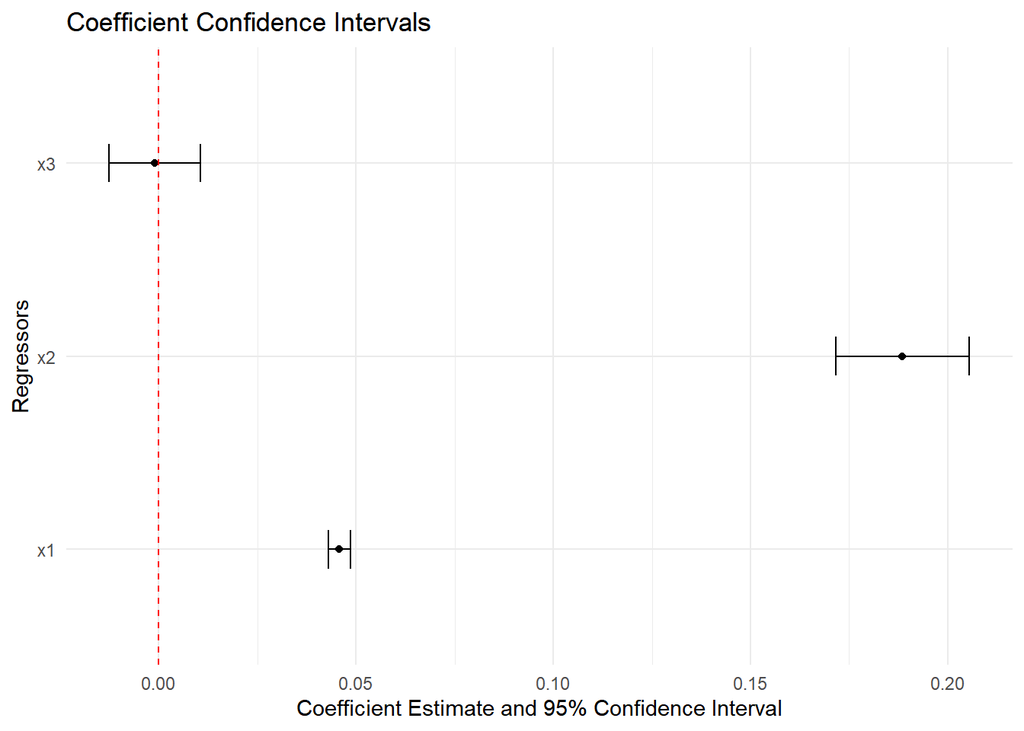

```r
plot_coef_intervals <- function(model) {
  coefs <- as.data.frame(summary(model)$coefficients)
  conf_intervals <- confint(model)
  plot_data <- data.frame(
    term = rownames(coefs),
    estimate = coefs$Estimate,
    lower = conf_intervals[, 1],
    upper = conf_intervals[, 2]
  )

  plot_data <- plot_data[plot_data$term != "(Intercept)", ]#intercept excluded

   ggplot(plot_data, aes(x = term, y = estimate, ymin = lower, ymax = upper)) +
    geom_point() +
    geom_errorbar(width = 0.2) +
    geom_hline(yintercept = 0, linetype = "dashed", color = "red") +
    coord_flip() +
    labs(
      title = "Coefficient Confidence Intervals",
      x = "Regressors",
      y = "Coefficient Estimate and 95% Confidence Interval"
    ) +
    theme_minimal()
}
plot_coef_intervals(fit_full)
```

As expected, the only confidence interval containing 0 is the one corresponding to $x_3=\textrm{newspaper}$, which means that we may discard *newspaper* as a predictor if we wish. Note that this is consistent with the large $p$-value for the relevant $\mathfrak t$-test in the summary ($\approx 0.86$)[^3]. Applying *backward selection*, we now fit the partial model…

```r
fit_partial <- lm(y ~ x1 + x2, data = dat)
summary(fit_partial)
```

```
##
## Call:
## lm(formula = y ~ x1 + x2, data = dat)
##
## Residuals:
##     Min      1Q  Median      3Q     Max
## -8.7977 -0.8752  0.2422  1.1708  2.8328
##
## Coefficients:
##             Estimate Std. Error t value Pr(>|t|)
## (Intercept)  2.92110    0.29449   9.919   <2e-16 ***
## x1           0.04575    0.00139  32.909   <2e-16 ***
## x2           0.18799    0.00804  23.382   <2e-16 ***
## ---
## Signif. codes:  0 '***' 0.001 '**' 0.01 '*' 0.05 '.' 0.1 ' ' 1
##
## Residual standard error: 1.681 on 197 degrees of freedom
## Multiple R-squared:  0.8972, Adjusted R-squared:  0.8962
## F-statistic: 859.6 on 2 and 197 DF,  p-value: < 2.2e-16
```

…from whose summary we may extract the estimated coefficients…

```r
coef(fit_partial)
```

```
## (Intercept)          x1          x2
##  2.92109991  0.04575482  0.18799423
```

… and the confidence intervals…

```r
confint(fit_partial)
```

```
##                  2.5 %     97.5 %
## (Intercept) 2.34034299 3.50185683
## x1          0.04301292 0.04849671
## x2          0.17213877 0.20384969
```

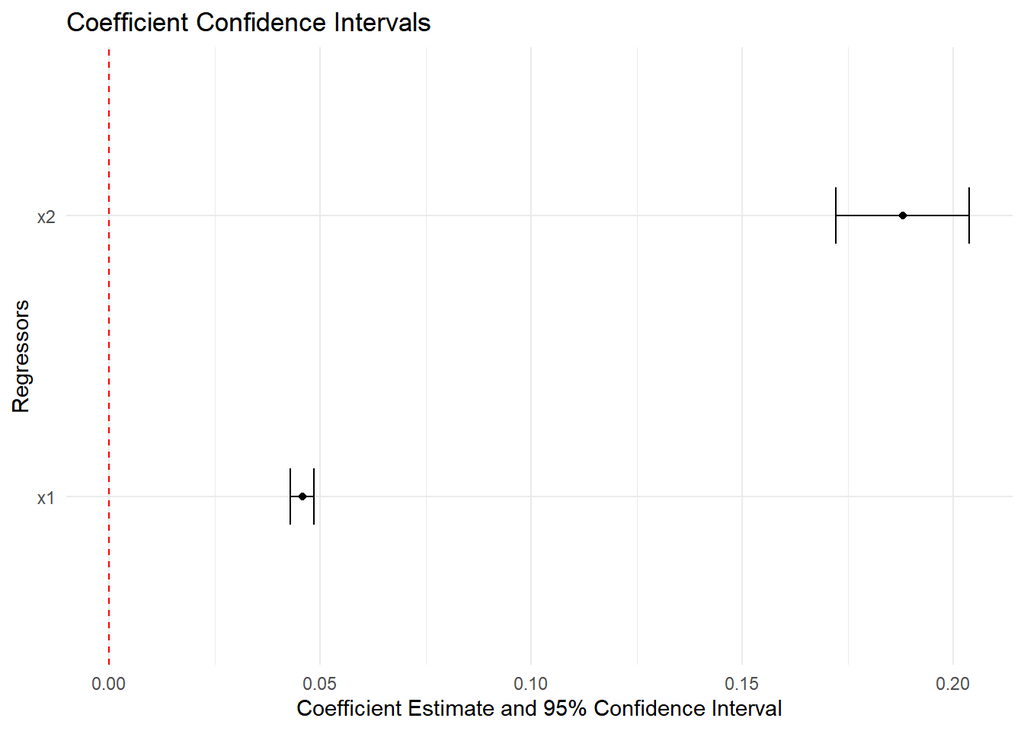

```r
plot_coef_intervals(fit_partial)
```

…which indicates that the remaining regressors ($x_1=\textrm{TV}$ and $x_2=\textrm{radio}$) are both statistically significant and should be retained in the model.

As in the companion lab, we may run an ANOVA test to compare the models…

```r
anova(fit_partial,fit_full)
```

```
## Analysis of Variance Table
##
## Model 1: y ~ x1 + x2
## Model 2: y ~ x1 + x2 + x3
##   Res.Df    RSS Df Sum of Sq      F Pr(>F)
## 1    197 556.91
## 2    196 556.83  1  0.088717 0.0312 0.8599
```

…so that the large *p*-value (*~0.86*) confirms that the null model (*fit_partial*) should *not* be rejected, so we may safely discard $x_3=\textrm{newspaper}$ from our original model.

The point of the present discussion, however, is to check that the information-theoretic mechanism in the AICs may be used to confirm this kind of decision (based on backward selection). Recall that the AIC of a linear model as above is given by
$$\mathrm{AIC} = n\log(\widehat{\sigma}^2_{ML}) + 2(k+2)+n(\log(2\pi)+1).$$
Here,
$$\widehat{\sigma}^2_{ML} = \frac{\mathrm{RSS}}{n}$$
is the MLE of $\sigma^2$, where $\mathrm{RSS}$ is the **residual sum of squares**, and $k$ is the number of regressors, excluding the intercept (thus, $k=3$ for `fit_full` and $k=2$ for `fit_partial`). Thus, we see here a sort of penalization operating in the final expression for the AIC, which somehow detects the complexity of the model as described by the number of its regressors.

We may use this textbook formula to directly compute the AIC of any model. For instance, for the full model we may extract $\mathrm{RSS}$ and compute $\widehat{\sigma}^2_{ML}$ as follows…

```r
rss_full <- sum(residuals(fit_full)^2)
sig2hat_full <- rss_full / n
rss_full
```

```
## [1] 556.8253
```

```r
sig2hat_full
```

```
## [1] 2.784126
```

…and then compute the AIC by means of the appropriate function…

```r
aic_book <- function(sig2hat, k, n){
  n*(log(2*pi) + 1) + n*log(sig2hat) + 2*(k + 2)
}

AIC_full_book <- aic_book(sig2hat_full, k = 3, n = n)
AIC_full_book
```

```
## [1] 782.3622
```

…which should be compared to the output of the built-in function in R:

```r
AIC(fit_full)
```

```
## [1] 782.3622
```

R also has a built-in function that allows us to compare the AIC for a pair of models. In our case…

```r
AIC(fit_partial,fit_full)
```

```
##             df      AIC
## fit_partial  4 780.3941
## fit_full     5 782.3622
```

…and we see that, from this information-theoretic viewpoint, there appears a slight preference for `fit_partial` (with $|\Delta|\approx 1.97$), which aligns with our previous analysis based on backward selection.

But we can go one step further by fitting all subset models based on $\{x_1, x_2, x_3\}$, including the intercept-only model, and extract the corresponding AICs, which allows us to effectively compare all such models from an information-theoretic perspective.

```r
fit_subset <- function(vars, dat){
  if(length(vars) == 0){
    form <- as.formula("y ~ 1")
  } else {
    form <- as.formula(paste("y ~", paste(vars, collapse = " + ")))
  }
  lm(form, data = dat)
}

all_models <- list(
  "x1+x2"    = c("x1","x2"),
  "x1+x2+x3" = c("x1","x2","x3"),
  "x1+x3"    = c("x1","x3"),
  "x1"       = c("x1"),
  "x2+x3"    = c("x2","x3"),
  "x2"       = c("x2"),
  "x3"       = c("x3"),
  "none"     = character(0)
)

res_table <- do.call(rbind, lapply(names(all_models), function(name){
  vars <- all_models[[name]]
  k <- length(vars)
  fit <- fit_subset(vars, dat)
  rss <- sum(residuals(fit)^2)
  sig2hat <- rss / n
  aic <- aic_book(sig2hat, k = k, n = n)
  coefs <- coef(fit)

  b0 <- unname(coefs["(Intercept)"])
  b1 <- if("x1" %in% names(coefs)) unname(coefs["x1"]) else NA_real_
  b2 <- if("x2" %in% names(coefs)) unname(coefs["x2"]) else NA_real_
  b3 <- if("x3" %in% names(coefs)) unname(coefs["x3"]) else NA_real_

  data.frame(
    model = name,
    k = k,
    sig2hat = sig2hat,
    AIC_book = aic,
    b0 = b0, b1 = b1, b2 = b2, b3 = b3,
    row.names = NULL
  )
}))
```

We may now print the output with the AICs displayed in an increasing order (and with *b_i* indicating the corresponding estimated coefficient)…

```r
res_table <- res_table[order(res_table$AIC_book), ]
res_table
```

```
##      model k   sig2hat  AIC_book        b0         b1        b2           b3
## 1    x1+x2 2  2.784570  780.3941  2.921100 0.04575482 0.1879942           NA
## 2 x1+x2+x3 3  2.784126  782.3622  2.938889 0.04576465 0.1885300 -0.001037493
## 3    x1+x3 2  9.592809 1027.7782  5.774948 0.04690121        NA  0.044219424
## 4       x1 1 10.512653 1044.0913  7.032594 0.04753664        NA           NA
## 6       x2 1 18.092398 1152.6738  9.311638         NA 0.2024958           NA
## 5    x2+x3 2 18.074176 1154.4723  9.188920         NA 0.1990446  0.006644175
## 7       x3 1 25.674023 1222.6714 12.351407         NA        NA  0.054693098
## 8     none 0 27.085744 1231.3769 14.022500         NA        NA           NA
```

…to confirm that, from the AIC viewpoint, *fit_partial* qualifies as the best model (not only if compared to *fit_full* but also among all possible sub-models) .

We may also visualize the AIC workflow as regressors are added (starting with the intercept-only model). For this we must compute, for each $k=0,1,2,3$, the minimum AIC among all models that use exactly $k$ regressors.

```r
aic_path <- function(dat){
  yname <- "y"
  xnames <- setdiff(names(dat), yname)
  n <- nrow(dat)
  p <- length(xnames)

  aic_min <- numeric(p + 1)

  for(k in 0:p){
    if(k == 0){
      fit <- lm(y ~ 1, data = dat)
      rss <- sum(residuals(fit)^2)
      aic_min[k+1] <- aic_book(rss/n, k = 0, n = n)
    } else {
      combos <- combn(xnames, k, simplify = FALSE)
      aics <- sapply(combos, function(vars){
        form <- as.formula(paste("y ~", paste(vars, collapse = "+")))
        fit <- lm(form, data = dat)
        rss <- sum(residuals(fit)^2)
        aic_book(rss/n, k = k, n = n)
      })
      aic_min[k+1] <- min(aics)
    }
  }

  data.frame(k = 0:p, AIC_MIN = aic_min)
}
```

We may either display the output as a simple table…

```r
aic_df <- aic_path(dat)
aic_df
```

```
##   k   AIC_MIN
## 1 0 1231.3769
## 2 1 1044.0913
## 3 2  780.3941
## 4 3  782.3622
```

…or make it available as a plot…

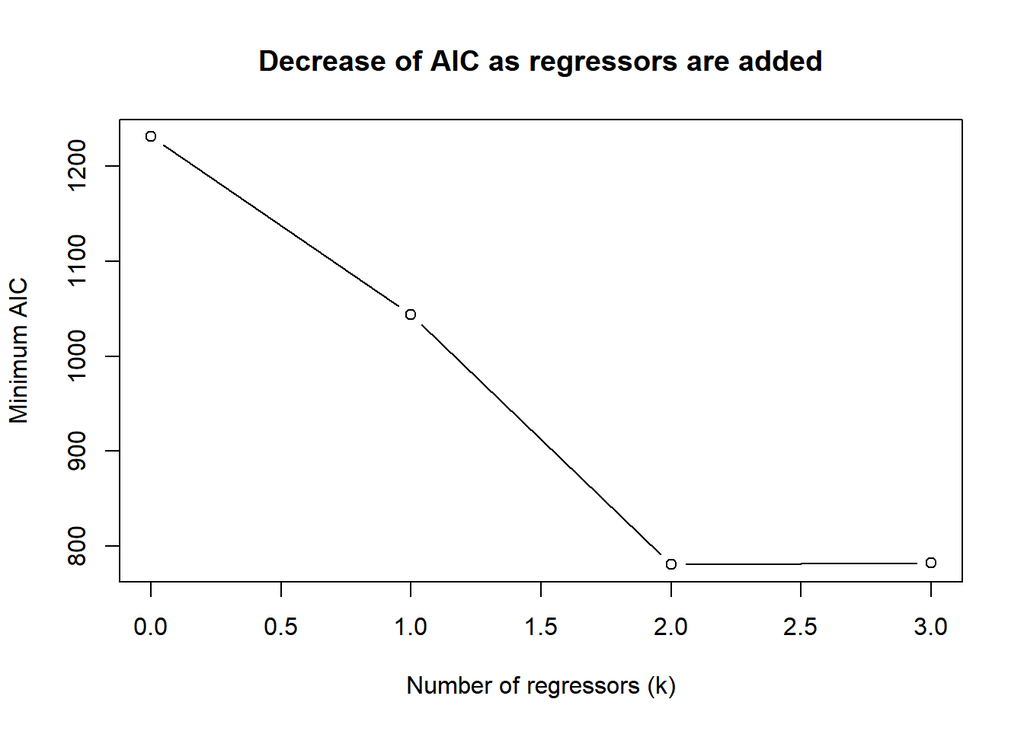

```r
plot(aic_df$k, aic_df$AIC, type = "b",
     xlab = "Number of regressors (k)",
     ylab = "Minimum AIC",
     main = "Decrease of AIC as regressors are added")
```

Burnham, Kenneth P, and David R Anderson. 2013. *Model Selection and Inference: A Practical Information-Theoretic Approach*. Springer Science & Business Media.

Konishi, Sadanori, and Genshiro Kitagawa. 2008. *Information Criteria and Statistical Modeling*. Springer.

Lima, Levi Lopes de. 2025. “Topics in Probability, Parametric Estimation and Stochastic Calculus.” https://arxiv.org/abs/2510.20163.

[^1]: For more on MLE, see the companion lab `MLE with Gamma-f`, available at [Github](https://github.com/levilopesdelima/stat-inference-labs).
[^2]: `Advertising-f` available at [Github](https://github.com/levilopesdelima/stat-inference-labs).
[^3]: Recall that this provides statistical evidence for *not* rejecting the corresponding **null hypothesis** (in this case, $\beta_3=0$).